# Risk Factor Analysis

## Outcome Variable

**Outcome Variable:** whz

## Predictor Variables

**Intervention Variable:** earlybf

**Adjustment Set:**

unadjusted

## Stratifying Variables

The analysis was stratified on these variable(s):

- agecat
- studyid
- country

## Data Summary

| agecat | studyid | country | earlybf | n_cell | n |
| --- | --- | --- | --- | --- | --- |
| Birth | EE | PAKISTAN | 1 | 36 | 170 |
| Birth | EE | PAKISTAN | 0 | 134 | 170 |
| Birth | GMS-Nepal | NEPAL | 1 | 171 | 586 |
| Birth | GMS-Nepal | NEPAL | 0 | 415 | 586 |
| Birth | MAL-ED | BANGLADESH | 1 | 140 | 214 |
| Birth | MAL-ED | BANGLADESH | 0 | 74 | 214 |
| Birth | MAL-ED | BRAZIL | 1 | 26 | 62 |
| Birth | MAL-ED | BRAZIL | 0 | 36 | 62 |
| Birth | MAL-ED | INDIA | 1 | 31 | 44 |
| Birth | MAL-ED | INDIA | 0 | 13 | 44 |
| Birth | MAL-ED | NEPAL | 1 | 14 | 26 |
| Birth | MAL-ED | NEPAL | 0 | 12 | 26 |
| Birth | MAL-ED | PERU | 1 | 172 | 228 |
| Birth | MAL-ED | PERU | 0 | 56 | 228 |
| Birth | MAL-ED | SOUTH AFRICA | 1 | 69 | 110 |
| Birth | MAL-ED | SOUTH AFRICA | 0 | 41 | 110 |
| Birth | MAL-ED | TANZANIA, UNITED REPUBLIC OF | 1 | 103 | 115 |
| Birth | MAL-ED | TANZANIA, UNITED REPUBLIC OF | 0 | 12 | 115 |
| Birth | NIH-Crypto | BANGLADESH | 1 | 613 | 707 |
| Birth | NIH-Crypto | BANGLADESH | 0 | 94 | 707 |
| Birth | SAS-CompFeed | INDIA | 1 | 79 | 1072 |
| Birth | SAS-CompFeed | INDIA | 0 | 993 | 1072 |
| Birth | ZVITAMBO | ZIMBABWE | 1 | 6142 | 11514 |
| Birth | ZVITAMBO | ZIMBABWE | 0 | 5372 | 11514 |
| 6 months | EE | PAKISTAN | 1 | 69 | 364 |
| 6 months | EE | PAKISTAN | 0 | 295 | 364 |
| 6 months | GMS-Nepal | NEPAL | 1 | 151 | 511 |
| 6 months | GMS-Nepal | NEPAL | 0 | 360 | 511 |
| 6 months | MAL-ED | BANGLADESH | 1 | 147 | 240 |
| 6 months | MAL-ED | BANGLADESH | 0 | 93 | 240 |
| 6 months | MAL-ED | BRAZIL | 1 | 95 | 209 |
| 6 months | MAL-ED | BRAZIL | 0 | 114 | 209 |
| 6 months | MAL-ED | INDIA | 1 | 140 | 236 |
| 6 months | MAL-ED | INDIA | 0 | 96 | 236 |
| 6 months | MAL-ED | NEPAL | 1 | 96 | 236 |
| 6 months | MAL-ED | NEPAL | 0 | 140 | 236 |
| 6 months | MAL-ED | PERU | 1 | 202 | 273 |
| 6 months | MAL-ED | PERU | 0 | 71 | 273 |
| 6 months | MAL-ED | SOUTH AFRICA | 1 | 156 | 250 |
| 6 months | MAL-ED | SOUTH AFRICA | 0 | 94 | 250 |
| 6 months | MAL-ED | TANZANIA, UNITED REPUBLIC OF | 1 | 205 | 247 |
| 6 months | MAL-ED | TANZANIA, UNITED REPUBLIC OF | 0 | 42 | 247 |
| 6 months | NIH-Crypto | BANGLADESH | 1 | 619 | 715 |
| 6 months | NIH-Crypto | BANGLADESH | 0 | 96 | 715 |
| 6 months | SAS-CompFeed | INDIA | 1 | 97 | 1334 |
| 6 months | SAS-CompFeed | INDIA | 0 | 1237 | 1334 |
| 6 months | ZVITAMBO | ZIMBABWE | 1 | 4065 | 7553 |
| 6 months | ZVITAMBO | ZIMBABWE | 0 | 3488 | 7553 |
| 24 months | EE | PAKISTAN | 1 | 32 | 164 |
| 24 months | EE | PAKISTAN | 0 | 132 | 164 |
| 24 months | GMS-Nepal | NEPAL | 1 | 131 | 444 |
| 24 months | GMS-Nepal | NEPAL | 0 | 313 | 444 |
| 24 months | MAL-ED | BANGLADESH | 1 | 128 | 211 |
| 24 months | MAL-ED | BANGLADESH | 0 | 83 | 211 |
| 24 months | MAL-ED | BRAZIL | 1 | 80 | 169 |
| 24 months | MAL-ED | BRAZIL | 0 | 89 | 169 |
| 24 months | MAL-ED | INDIA | 1 | 134 | 227 |
| 24 months | MAL-ED | INDIA | 0 | 93 | 227 |
| 24 months | MAL-ED | NEPAL | 1 | 95 | 228 |
| 24 months | MAL-ED | NEPAL | 0 | 133 | 228 |
| 24 months | MAL-ED | PERU | 1 | 149 | 201 |
| 24 months | MAL-ED | PERU | 0 | 52 | 201 |
| 24 months | MAL-ED | SOUTH AFRICA | 1 | 144 | 235 |
| 24 months | MAL-ED | SOUTH AFRICA | 0 | 91 | 235 |
| 24 months | MAL-ED | TANZANIA, UNITED REPUBLIC OF | 1 | 180 | 214 |
| 24 months | MAL-ED | TANZANIA, UNITED REPUBLIC OF | 0 | 34 | 214 |
| 24 months | NIH-Crypto | BANGLADESH | 1 | 443 | 514 |
| 24 months | NIH-Crypto | BANGLADESH | 0 | 71 | 514 |
| 24 months | ZVITAMBO | ZIMBABWE | 1 | 201 | 379 |
| 24 months | ZVITAMBO | ZIMBABWE | 0 | 178 | 379 |

The following strata were considered:

- agecat: 24 months, studyid: EE, country: PAKISTAN
- agecat: 24 months, studyid: GMS-Nepal, country: NEPAL
- agecat: 24 months, studyid: MAL-ED, country: BANGLADESH
- agecat: 24 months, studyid: MAL-ED, country: BRAZIL
- agecat: 24 months, studyid: MAL-ED, country: INDIA
- agecat: 24 months, studyid: MAL-ED, country: NEPAL
- agecat: 24 months, studyid: MAL-ED, country: PERU
- agecat: 24 months, studyid: MAL-ED, country: SOUTH AFRICA
- agecat: 24 months, studyid: MAL-ED, country: TANZANIA, UNITED REPUBLIC OF
- agecat: 24 months, studyid: NIH-Crypto, country: BANGLADESH
- agecat: 24 months, studyid: ZVITAMBO, country: ZIMBABWE
- agecat: 6 months, studyid: EE, country: PAKISTAN
- agecat: 6 months, studyid: GMS-Nepal, country: NEPAL
- agecat: 6 months, studyid: MAL-ED, country: BANGLADESH
- agecat: 6 months, studyid: MAL-ED, country: BRAZIL
- agecat: 6 months, studyid: MAL-ED, country: INDIA
- agecat: 6 months, studyid: MAL-ED, country: NEPAL
- agecat: 6 months, studyid: MAL-ED, country: PERU
- agecat: 6 months, studyid: MAL-ED, country: SOUTH AFRICA
- agecat: 6 months, studyid: MAL-ED, country: TANZANIA, UNITED REPUBLIC OF
- agecat: 6 months, studyid: NIH-Crypto, country: BANGLADESH
- agecat: 6 months, studyid: SAS-CompFeed, country: INDIA
- agecat: 6 months, studyid: ZVITAMBO, country: ZIMBABWE
- agecat: Birth, studyid: EE, country: PAKISTAN
- agecat: Birth, studyid: GMS-Nepal, country: NEPAL
- agecat: Birth, studyid: MAL-ED, country: BANGLADESH
- agecat: Birth, studyid: MAL-ED, country: BRAZIL
- agecat: Birth, studyid: MAL-ED, country: INDIA
- agecat: Birth, studyid: MAL-ED, country: NEPAL
- agecat: Birth, studyid: MAL-ED, country: PERU
- agecat: Birth, studyid: MAL-ED, country: SOUTH AFRICA
- agecat: Birth, studyid: MAL-ED, country: TANZANIA, UNITED REPUBLIC OF
- agecat: Birth, studyid: NIH-Crypto, country: BANGLADESH
- agecat: Birth, studyid: SAS-CompFeed, country: INDIA
- agecat: Birth, studyid: ZVITAMBO, country: ZIMBABWE

## Methods Detail

We’re interested in the causal parameters $E[Y_a]$ for all values of $a \in \mathcal{A}$. These parameters represent the mean outcome if, possibly contrary to fact, we intervened to set all units to have $A=a$. Under the randomization and positivity assumptions, these are identified by the statistical parameters $\psi_a=E_W[E_{Y|A,W}(Y|A=a,W)]$. In addition, we’re interested in the mean of $Y$, $E[Y]$ under no intervention (the observed mean). We will estimate these parameters by using SuperLearner to fit the relevant likelihood factors – $E_{Y|A,W}(Y|A=a,W)$ and $p(A=a|W)$, and then updating our likelihood fit using a joint TMLE.

For unadjusted analyses ($W=\{\}$), initial likelihoods were estimated using Lrnr_glm to estimate the simple $E(Y|A)$ and Lrnr_mean to estimate $p(A)$. For adjusted analyses, a small library containing Lrnr_glmnet, Lrnr_xgboost, and Lrnr_mean was used.

Having estimated these parameters, we will then use the delta method to estimate relative risks and attributable risks relative to a prespecified baseline level of $A$.

# Results Detail

## Results Plots

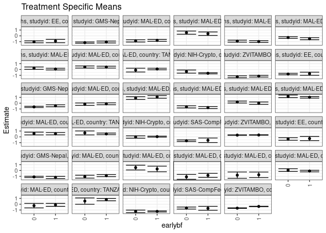

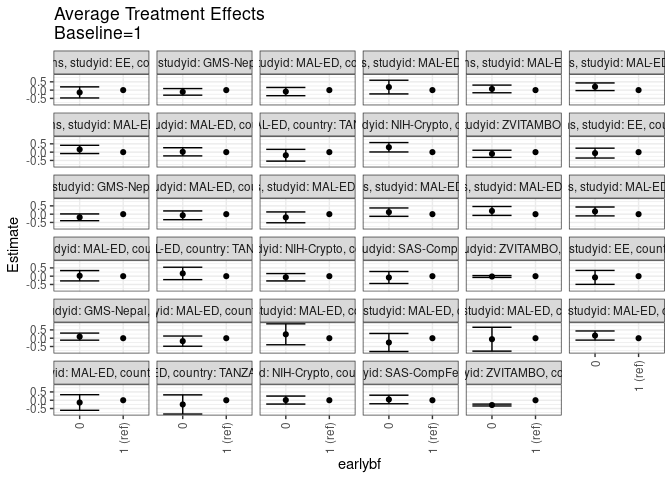

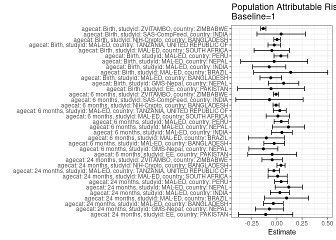

## Results Table

### Parameter: TSM

| agecat | studyid | country | intervention_level | baseline_level | estimate | ci_lower | ci_upper |
| --- | --- | --- | --- | --- | --- | --- | --- |
| Birth | EE | PAKISTAN | 1 | NA | -0.2937500 | -0.6510553 | 0.0635553 |
| Birth | EE | PAKISTAN | 0 | NA | -0.3679104 | -0.5898401 | -0.1459808 |
| Birth | GMS-Nepal | NEPAL | 1 | NA | -1.1930409 | -1.3769685 | -1.0091133 |
| Birth | GMS-Nepal | NEPAL | 0 | NA | -1.0984578 | -1.2045001 | -0.9924155 |
| Birth | MAL-ED | BANGLADESH | 1 | NA | -0.8778929 | -1.0555336 | -0.7002521 |
| Birth | MAL-ED | BANGLADESH | 0 | NA | -1.0547973 | -1.3068213 | -0.8027733 |
| Birth | MAL-ED | BRAZIL | 1 | NA | 0.2661538 | -0.2148460 | 0.7471537 |
| Birth | MAL-ED | BRAZIL | 0 | NA | 0.5016667 | 0.0920386 | 0.9112947 |
| Birth | MAL-ED | INDIA | 1 | NA | -0.8358065 | -1.1855339 | -0.4860790 |
| Birth | MAL-ED | INDIA | 0 | NA | -1.0946154 | -1.5115252 | -0.6777056 |
| Birth | MAL-ED | NEPAL | 1 | NA | -0.7407143 | -1.2154214 | -0.2660071 |
| Birth | MAL-ED | NEPAL | 0 | NA | -0.8008333 | -1.3411944 | -0.2604722 |
| Birth | MAL-ED | PERU | 1 | NA | -0.0916279 | -0.2306469 | 0.0473911 |
| Birth | MAL-ED | PERU | 0 | NA | 0.0696429 | -0.1692599 | 0.3085456 |
| Birth | MAL-ED | SOUTH AFRICA | 1 | NA | -0.1181159 | -0.3765177 | 0.1402859 |
| Birth | MAL-ED | SOUTH AFRICA | 0 | NA | -0.2546341 | -0.6484825 | 0.1392142 |
| Birth | MAL-ED | TANZANIA, UNITED REPUBLIC OF | 1 | NA | 0.7890291 | 0.5855277 | 0.9925305 |
| Birth | MAL-ED | TANZANIA, UNITED REPUBLIC OF | 0 | NA | 0.5341667 | -0.0074827 | 1.0758161 |
| Birth | NIH-Crypto | BANGLADESH | 1 | NA | -1.2455220 | -1.3360815 | -1.1549625 |
| Birth | NIH-Crypto | BANGLADESH | 0 | NA | -1.2352128 | -1.4588688 | -1.0115567 |
| Birth | SAS-CompFeed | INDIA | 1 | NA | -0.7096203 | -1.0467907 | -0.3724498 |
| Birth | SAS-CompFeed | INDIA | 0 | NA | -0.6642598 | -0.8346897 | -0.4938300 |
| Birth | ZVITAMBO | ZIMBABWE | 1 | NA | -0.3911934 | -0.4271181 | -0.3552687 |
| Birth | ZVITAMBO | ZIMBABWE | 0 | NA | -0.6805789 | -0.7225287 | -0.6386291 |
| 6 months | EE | PAKISTAN | 1 | NA | -0.7251691 | -0.9952206 | -0.4551175 |
| 6 months | EE | PAKISTAN | 0 | NA | -0.7836667 | -0.9109267 | -0.6564067 |
| 6 months | GMS-Nepal | NEPAL | 1 | NA | -0.4498013 | -0.6233029 | -0.2762997 |
| 6 months | GMS-Nepal | NEPAL | 0 | NA | -0.6408194 | -0.7484182 | -0.5332207 |
| 6 months | MAL-ED | BANGLADESH | 1 | NA | -0.1043424 | -0.2683629 | 0.0596781 |
| 6 months | MAL-ED | BANGLADESH | 0 | NA | -0.1747491 | -0.3823526 | 0.0328544 |
| 6 months | MAL-ED | BRAZIL | 1 | NA | 1.0772982 | 0.8432744 | 1.3113221 |
| 6 months | MAL-ED | BRAZIL | 0 | NA | 0.8843933 | 0.6561718 | 1.1126148 |
| 6 months | MAL-ED | INDIA | 1 | NA | -0.7573036 | -0.9268395 | -0.5877676 |
| 6 months | MAL-ED | INDIA | 0 | NA | -0.6360938 | -0.8234633 | -0.4487242 |
| 6 months | MAL-ED | NEPAL | 1 | NA | -0.0043750 | -0.2146179 | 0.2058679 |
| 6 months | MAL-ED | NEPAL | 0 | NA | 0.1891548 | 0.0224772 | 0.3558323 |
| 6 months | MAL-ED | PERU | 1 | NA | 1.0103672 | 0.8671347 | 1.1535997 |
| 6 months | MAL-ED | PERU | 0 | NA | 1.1738380 | 0.9471017 | 1.4005743 |
| 6 months | MAL-ED | SOUTH AFRICA | 1 | NA | 0.5403205 | 0.3400433 | 0.7405977 |
| 6 months | MAL-ED | SOUTH AFRICA | 0 | NA | 0.5661348 | 0.3289872 | 0.8032823 |
| 6 months | MAL-ED | TANZANIA, UNITED REPUBLIC OF | 1 | NA | 0.5080976 | 0.3669612 | 0.6492339 |
| 6 months | MAL-ED | TANZANIA, UNITED REPUBLIC OF | 0 | NA | 0.6734921 | 0.3278856 | 1.0190986 |
| 6 months | NIH-Crypto | BANGLADESH | 1 | NA | 0.0384410 | -0.0470142 | 0.1238963 |
| 6 months | NIH-Crypto | BANGLADESH | 0 | NA | -0.0261979 | -0.2307354 | 0.1783396 |
| 6 months | SAS-CompFeed | INDIA | 1 | NA | -0.5918557 | -0.9793684 | -0.2043429 |
| 6 months | SAS-CompFeed | INDIA | 0 | NA | -0.6714996 | -0.8053035 | -0.5376957 |
| 6 months | ZVITAMBO | ZIMBABWE | 1 | NA | 0.3159914 | 0.2793274 | 0.3526553 |
| 6 months | ZVITAMBO | ZIMBABWE | 0 | NA | 0.2970915 | 0.2563194 | 0.3378635 |
| 24 months | EE | PAKISTAN | 1 | NA | -0.8925000 | -1.1793422 | -0.6056578 |
| 24 months | EE | PAKISTAN | 0 | NA | -1.0315909 | -1.2040717 | -0.8591101 |
| 24 months | GMS-Nepal | NEPAL | 1 | NA | -1.0590840 | -1.2223257 | -0.8958423 |
| 24 months | GMS-Nepal | NEPAL | 0 | NA | -1.1652982 | -1.2775264 | -1.0530699 |
| 24 months | MAL-ED | BANGLADESH | 1 | NA | -0.7790234 | -0.9367823 | -0.6212646 |
| 24 months | MAL-ED | BANGLADESH | 0 | NA | -0.8683735 | -1.0607056 | -0.6760414 |
| 24 months | MAL-ED | BRAZIL | 1 | NA | 0.3668750 | 0.0581878 | 0.6755622 |
| 24 months | MAL-ED | BRAZIL | 0 | NA | 0.5486891 | 0.2745441 | 0.8228341 |
| 24 months | MAL-ED | INDIA | 1 | NA | -0.9808955 | -1.1360252 | -0.8257659 |
| 24 months | MAL-ED | INDIA | 0 | NA | -0.9095161 | -1.0806109 | -0.7384213 |
| 24 months | MAL-ED | NEPAL | 1 | NA | -0.4927895 | -0.6715978 | -0.3139811 |
| 24 months | MAL-ED | NEPAL | 0 | NA | -0.2907143 | -0.4362552 | -0.1451733 |
| 24 months | MAL-ED | PERU | 1 | NA | 0.0690660 | -0.0814285 | 0.2195605 |
| 24 months | MAL-ED | PERU | 0 | NA | 0.2319231 | 0.0350203 | 0.4288259 |
| 24 months | MAL-ED | SOUTH AFRICA | 1 | NA | 0.4080382 | 0.2463428 | 0.5697336 |
| 24 months | MAL-ED | SOUTH AFRICA | 0 | NA | 0.4267766 | 0.2411535 | 0.6123996 |
| 24 months | MAL-ED | TANZANIA, UNITED REPUBLIC OF | 1 | NA | 0.0847593 | -0.0500331 | 0.2195516 |
| 24 months | MAL-ED | TANZANIA, UNITED REPUBLIC OF | 0 | NA | -0.1038235 | -0.4320147 | 0.2243676 |
| 24 months | NIH-Crypto | BANGLADESH | 1 | NA | -0.6509029 | -0.7516783 | -0.5501275 |
| 24 months | NIH-Crypto | BANGLADESH | 0 | NA | -0.3573239 | -0.6224217 | -0.0922262 |
| 24 months | ZVITAMBO | ZIMBABWE | 1 | NA | -1.1498010 | -1.2931439 | -1.0064581 |
| 24 months | ZVITAMBO | ZIMBABWE | 0 | NA | -1.2504494 | -1.4119363 | -1.0889626 |

### Parameter: E(Y)

| agecat | studyid | country | intervention_level | baseline_level | estimate | ci_lower | ci_upper |
| --- | --- | --- | --- | --- | --- | --- | --- |
| Birth | EE | PAKISTAN | NA | NA | -0.3522059 | -0.5428560 | -0.1615557 |
| Birth | GMS-Nepal | NEPAL | NA | NA | -1.1260580 | -1.2184297 | -1.0336863 |
| Birth | MAL-ED | BANGLADESH | NA | NA | -0.9390654 | -1.0847642 | -0.7933666 |
| Birth | MAL-ED | BRAZIL | NA | NA | 0.4029032 | 0.0896793 | 0.7161272 |
| Birth | MAL-ED | INDIA | NA | NA | -0.9122727 | -1.1899971 | -0.6345483 |
| Birth | MAL-ED | NEPAL | NA | NA | -0.7684615 | -1.1257770 | -0.4111460 |
| Birth | MAL-ED | PERU | NA | NA | -0.0520175 | -0.1725298 | 0.0684947 |
| Birth | MAL-ED | SOUTH AFRICA | NA | NA | -0.1690000 | -0.3880340 | 0.0500340 |
| Birth | MAL-ED | TANZANIA, UNITED REPUBLIC OF | NA | NA | 0.7624348 | 0.5710709 | 0.9537986 |
| Birth | NIH-Crypto | BANGLADESH | NA | NA | -1.2441513 | -1.3281130 | -1.1601897 |
| Birth | SAS-CompFeed | INDIA | NA | NA | -0.6676026 | -0.8422097 | -0.4929956 |
| Birth | ZVITAMBO | ZIMBABWE | NA | NA | -0.5262098 | -0.5537283 | -0.4986913 |
| 6 months | EE | PAKISTAN | NA | NA | -0.7725778 | -0.8877440 | -0.6574117 |
| 6 months | GMS-Nepal | NEPAL | NA | NA | -0.5843738 | -0.6761994 | -0.4925481 |
| 6 months | MAL-ED | BANGLADESH | NA | NA | -0.1316250 | -0.2604010 | -0.0028490 |
| 6 months | MAL-ED | BRAZIL | NA | NA | 0.9720774 | 0.8078144 | 1.1363403 |
| 6 months | MAL-ED | INDIA | NA | NA | -0.7079979 | -0.8344175 | -0.5815783 |
| 6 months | MAL-ED | NEPAL | NA | NA | 0.1104308 | -0.0208643 | 0.2417259 |
| 6 months | MAL-ED | PERU | NA | NA | 1.0528816 | 0.9313005 | 1.1744626 |
| 6 months | MAL-ED | SOUTH AFRICA | NA | NA | 0.5500267 | 0.3964966 | 0.7035568 |
| 6 months | MAL-ED | TANZANIA, UNITED REPUBLIC OF | NA | NA | 0.5362213 | 0.4049390 | 0.6675036 |
| 6 months | NIH-Crypto | BANGLADESH | NA | NA | 0.0297622 | -0.0491685 | 0.1086930 |
| 6 months | SAS-CompFeed | INDIA | NA | NA | -0.6657084 | -0.8024377 | -0.5289791 |
| 6 months | ZVITAMBO | ZIMBABWE | NA | NA | 0.3072633 | 0.2799882 | 0.3345385 |
| 24 months | EE | PAKISTAN | NA | NA | -1.0044512 | -1.1543739 | -0.8545285 |
| 24 months | GMS-Nepal | NEPAL | NA | NA | -1.1339602 | -1.2266932 | -1.0412272 |
| 24 months | MAL-ED | BANGLADESH | NA | NA | -0.8141706 | -0.9363085 | -0.6920327 |
| 24 months | MAL-ED | BRAZIL | NA | NA | 0.4626233 | 0.2567495 | 0.6684971 |
| 24 months | MAL-ED | INDIA | NA | NA | -0.9516520 | -1.0670654 | -0.8362385 |
| 24 months | MAL-ED | NEPAL | NA | NA | -0.3749123 | -0.4886073 | -0.2612173 |
| 24 months | MAL-ED | PERU | NA | NA | 0.1111982 | -0.0118399 | 0.2342362 |
| 24 months | MAL-ED | SOUTH AFRICA | NA | NA | 0.4152943 | 0.2928804 | 0.5377083 |
| 24 months | MAL-ED | TANZANIA, UNITED REPUBLIC OF | NA | NA | 0.0547975 | -0.0703378 | 0.1799328 |
| 24 months | NIH-Crypto | BANGLADESH | NA | NA | -0.6103502 | -0.7050157 | -0.5156847 |
| 24 months | ZVITAMBO | ZIMBABWE | NA | NA | -1.1970712 | -1.3045749 | -1.0895676 |

### Parameter: ATE

| agecat | studyid | country | intervention_level | baseline_level | estimate | ci_lower | ci_upper |
| --- | --- | --- | --- | --- | --- | --- | --- |
| Birth | EE | PAKISTAN | 1 | 1 | 0.0000000 | 0.0000000 | 0.0000000 |
| Birth | EE | PAKISTAN | 0 | 1 | -0.0741604 | -0.4947788 | 0.3464580 |
| Birth | GMS-Nepal | NEPAL | 1 | 1 | 0.0000000 | 0.0000000 | 0.0000000 |
| Birth | GMS-Nepal | NEPAL | 0 | 1 | 0.0945831 | -0.1177240 | 0.3068903 |
| Birth | MAL-ED | BANGLADESH | 1 | 1 | 0.0000000 | 0.0000000 | 0.0000000 |
| Birth | MAL-ED | BANGLADESH | 0 | 1 | -0.1769044 | -0.4852425 | 0.1314336 |
| Birth | MAL-ED | BRAZIL | 1 | 1 | 0.0000000 | 0.0000000 | 0.0000000 |
| Birth | MAL-ED | BRAZIL | 0 | 1 | 0.2355128 | -0.3962751 | 0.8673008 |
| Birth | MAL-ED | INDIA | 1 | 1 | 0.0000000 | 0.0000000 | 0.0000000 |
| Birth | MAL-ED | INDIA | 0 | 1 | -0.2588089 | -0.8029809 | 0.2853630 |
| Birth | MAL-ED | NEPAL | 1 | 1 | 0.0000000 | 0.0000000 | 0.0000000 |
| Birth | MAL-ED | NEPAL | 0 | 1 | -0.0601190 | -0.7793805 | 0.6591424 |
| Birth | MAL-ED | PERU | 1 | 1 | 0.0000000 | 0.0000000 | 0.0000000 |
| Birth | MAL-ED | PERU | 0 | 1 | 0.1612708 | -0.1151362 | 0.4376777 |
| Birth | MAL-ED | SOUTH AFRICA | 1 | 1 | 0.0000000 | 0.0000000 | 0.0000000 |
| Birth | MAL-ED | SOUTH AFRICA | 0 | 1 | -0.1365182 | -0.6075681 | 0.3345317 |
| Birth | MAL-ED | TANZANIA, UNITED REPUBLIC OF | 1 | 1 | 0.0000000 | 0.0000000 | 0.0000000 |
| Birth | MAL-ED | TANZANIA, UNITED REPUBLIC OF | 0 | 1 | -0.2548625 | -0.8334788 | 0.3237539 |
| Birth | NIH-Crypto | BANGLADESH | 1 | 1 | 0.0000000 | 0.0000000 | 0.0000000 |
| Birth | NIH-Crypto | BANGLADESH | 0 | 1 | 0.0103093 | -0.2309853 | 0.2516038 |
| Birth | SAS-CompFeed | INDIA | 1 | 1 | 0.0000000 | 0.0000000 | 0.0000000 |
| Birth | SAS-CompFeed | INDIA | 0 | 1 | 0.0453604 | -0.2131946 | 0.3039154 |
| Birth | ZVITAMBO | ZIMBABWE | 1 | 1 | 0.0000000 | 0.0000000 | 0.0000000 |
| Birth | ZVITAMBO | ZIMBABWE | 0 | 1 | -0.2893855 | -0.3446157 | -0.2341554 |
| 6 months | EE | PAKISTAN | 1 | 1 | 0.0000000 | 0.0000000 | 0.0000000 |
| 6 months | EE | PAKISTAN | 0 | 1 | -0.0584976 | -0.3570322 | 0.2400371 |
| 6 months | GMS-Nepal | NEPAL | 1 | 1 | 0.0000000 | 0.0000000 | 0.0000000 |
| 6 months | GMS-Nepal | NEPAL | 0 | 1 | -0.1910181 | -0.3951757 | 0.0131394 |
| 6 months | MAL-ED | BANGLADESH | 1 | 1 | 0.0000000 | 0.0000000 | 0.0000000 |
| 6 months | MAL-ED | BANGLADESH | 0 | 1 | -0.0704067 | -0.3349855 | 0.1941721 |
| 6 months | MAL-ED | BRAZIL | 1 | 1 | 0.0000000 | 0.0000000 | 0.0000000 |
| 6 months | MAL-ED | BRAZIL | 0 | 1 | -0.1929050 | -0.5197875 | 0.1339776 |
| 6 months | MAL-ED | INDIA | 1 | 1 | 0.0000000 | 0.0000000 | 0.0000000 |
| 6 months | MAL-ED | INDIA | 0 | 1 | 0.1212098 | -0.1314753 | 0.3738949 |
| 6 months | MAL-ED | NEPAL | 1 | 1 | 0.0000000 | 0.0000000 | 0.0000000 |
| 6 months | MAL-ED | NEPAL | 0 | 1 | 0.1935298 | -0.0747676 | 0.4618271 |
| 6 months | MAL-ED | PERU | 1 | 1 | 0.0000000 | 0.0000000 | 0.0000000 |
| 6 months | MAL-ED | PERU | 0 | 1 | 0.1634709 | -0.1047173 | 0.4316590 |
| 6 months | MAL-ED | SOUTH AFRICA | 1 | 1 | 0.0000000 | 0.0000000 | 0.0000000 |
| 6 months | MAL-ED | SOUTH AFRICA | 0 | 1 | 0.0258142 | -0.2845885 | 0.3362170 |
| 6 months | MAL-ED | TANZANIA, UNITED REPUBLIC OF | 1 | 1 | 0.0000000 | 0.0000000 | 0.0000000 |
| 6 months | MAL-ED | TANZANIA, UNITED REPUBLIC OF | 0 | 1 | 0.1653945 | -0.2079195 | 0.5387085 |
| 6 months | NIH-Crypto | BANGLADESH | 1 | 1 | 0.0000000 | 0.0000000 | 0.0000000 |
| 6 months | NIH-Crypto | BANGLADESH | 0 | 1 | -0.0646390 | -0.2863103 | 0.1570324 |
| 6 months | SAS-CompFeed | INDIA | 1 | 1 | 0.0000000 | 0.0000000 | 0.0000000 |
| 6 months | SAS-CompFeed | INDIA | 0 | 1 | -0.0796439 | -0.4423738 | 0.2830860 |
| 6 months | ZVITAMBO | ZIMBABWE | 1 | 1 | 0.0000000 | 0.0000000 | 0.0000000 |
| 6 months | ZVITAMBO | ZIMBABWE | 0 | 1 | -0.0188999 | -0.0737325 | 0.0359326 |
| 24 months | EE | PAKISTAN | 1 | 1 | 0.0000000 | 0.0000000 | 0.0000000 |
| 24 months | EE | PAKISTAN | 0 | 1 | -0.1390909 | -0.4737968 | 0.1956150 |
| 24 months | GMS-Nepal | NEPAL | 1 | 1 | 0.0000000 | 0.0000000 | 0.0000000 |
| 24 months | GMS-Nepal | NEPAL | 0 | 1 | -0.1062142 | -0.3043128 | 0.0918843 |
| 24 months | MAL-ED | BANGLADESH | 1 | 1 | 0.0000000 | 0.0000000 | 0.0000000 |
| 24 months | MAL-ED | BANGLADESH | 0 | 1 | -0.0893501 | -0.3381060 | 0.1594059 |
| 24 months | MAL-ED | BRAZIL | 1 | 1 | 0.0000000 | 0.0000000 | 0.0000000 |
| 24 months | MAL-ED | BRAZIL | 0 | 1 | 0.1818141 | -0.2310336 | 0.5946619 |
| 24 months | MAL-ED | INDIA | 1 | 1 | 0.0000000 | 0.0000000 | 0.0000000 |
| 24 months | MAL-ED | INDIA | 0 | 1 | 0.0713794 | -0.1595722 | 0.3023310 |
| 24 months | MAL-ED | NEPAL | 1 | 1 | 0.0000000 | 0.0000000 | 0.0000000 |
| 24 months | MAL-ED | NEPAL | 0 | 1 | 0.2020752 | -0.0284776 | 0.4326280 |
| 24 months | MAL-ED | PERU | 1 | 1 | 0.0000000 | 0.0000000 | 0.0000000 |
| 24 months | MAL-ED | PERU | 0 | 1 | 0.1628571 | -0.0849721 | 0.4106863 |
| 24 months | MAL-ED | SOUTH AFRICA | 1 | 1 | 0.0000000 | 0.0000000 | 0.0000000 |
| 24 months | MAL-ED | SOUTH AFRICA | 0 | 1 | 0.0187384 | -0.2274350 | 0.2649117 |
| 24 months | MAL-ED | TANZANIA, UNITED REPUBLIC OF | 1 | 1 | 0.0000000 | 0.0000000 | 0.0000000 |
| 24 months | MAL-ED | TANZANIA, UNITED REPUBLIC OF | 0 | 1 | -0.1885828 | -0.5433763 | 0.1662107 |
| 24 months | NIH-Crypto | BANGLADESH | 1 | 1 | 0.0000000 | 0.0000000 | 0.0000000 |
| 24 months | NIH-Crypto | BANGLADESH | 0 | 1 | 0.2935790 | 0.0099727 | 0.5771853 |
| 24 months | ZVITAMBO | ZIMBABWE | 1 | 1 | 0.0000000 | 0.0000000 | 0.0000000 |
| 24 months | ZVITAMBO | ZIMBABWE | 0 | 1 | -0.1006484 | -0.3165771 | 0.1152802 |

### Parameter: PAR

| agecat | studyid | country | intervention_level | baseline_level | estimate | ci_lower | ci_upper |
| --- | --- | --- | --- | --- | --- | --- | --- |
| Birth | EE | PAKISTAN | 1 | NA | -0.0584559 | -0.3900336 | 0.2731219 |
| Birth | GMS-Nepal | NEPAL | 1 | NA | 0.0669829 | -0.0834115 | 0.2173773 |
| Birth | MAL-ED | BANGLADESH | 1 | NA | -0.0611726 | -0.1683912 | 0.0460461 |
| Birth | MAL-ED | BRAZIL | 1 | NA | 0.1367494 | -0.2312527 | 0.5047514 |
| Birth | MAL-ED | INDIA | 1 | NA | -0.0764663 | -0.2410725 | 0.0881399 |
| Birth | MAL-ED | NEPAL | 1 | NA | -0.0277473 | -0.3599219 | 0.3044274 |
| Birth | MAL-ED | PERU | 1 | NA | 0.0396104 | -0.0288770 | 0.1080978 |
| Birth | MAL-ED | SOUTH AFRICA | 1 | NA | -0.0508841 | -0.2268940 | 0.1251259 |
| Birth | MAL-ED | TANZANIA, UNITED REPUBLIC OF | 1 | NA | -0.0265943 | -0.0886426 | 0.0354539 |
| Birth | NIH-Crypto | BANGLADESH | 1 | NA | 0.0013707 | -0.0307120 | 0.0334533 |
| Birth | SAS-CompFeed | INDIA | 1 | NA | 0.0420176 | -0.1986263 | 0.2826616 |
| Birth | ZVITAMBO | ZIMBABWE | 1 | NA | -0.1350164 | -0.1609193 | -0.1091135 |
| 6 months | EE | PAKISTAN | 1 | NA | -0.0474088 | -0.2893645 | 0.1945470 |
| 6 months | GMS-Nepal | NEPAL | 1 | NA | -0.1345725 | -0.2786004 | 0.0094555 |
| 6 months | MAL-ED | BANGLADESH | 1 | NA | -0.0272826 | -0.1298991 | 0.0753339 |
| 6 months | MAL-ED | BRAZIL | 1 | NA | -0.1052209 | -0.2839977 | 0.0735559 |
| 6 months | MAL-ED | INDIA | 1 | NA | 0.0493057 | -0.0537630 | 0.1523744 |
| 6 months | MAL-ED | NEPAL | 1 | NA | 0.1148058 | -0.0448171 | 0.2744287 |
| 6 months | MAL-ED | PERU | 1 | NA | 0.0425144 | -0.0277529 | 0.1127817 |
| 6 months | MAL-ED | SOUTH AFRICA | 1 | NA | 0.0097062 | -0.1070156 | 0.1264279 |
| 6 months | MAL-ED | TANZANIA, UNITED REPUBLIC OF | 1 | NA | 0.0281238 | -0.0358278 | 0.0920753 |
| 6 months | NIH-Crypto | BANGLADESH | 1 | NA | -0.0086788 | -0.0384855 | 0.0211279 |
| 6 months | SAS-CompFeed | INDIA | 1 | NA | -0.0738527 | -0.4078671 | 0.2601617 |
| 6 months | ZVITAMBO | ZIMBABWE | 1 | NA | -0.0087281 | -0.0340508 | 0.0165947 |
| 24 months | EE | PAKISTAN | 1 | NA | -0.1119512 | -0.3814815 | 0.1575791 |
| 24 months | GMS-Nepal | NEPAL | 1 | NA | -0.0748762 | -0.2145996 | 0.0648471 |
| 24 months | MAL-ED | BANGLADESH | 1 | NA | -0.0351472 | -0.1331769 | 0.0628826 |
| 24 months | MAL-ED | BRAZIL | 1 | NA | 0.0957483 | -0.1221015 | 0.3135981 |
| 24 months | MAL-ED | INDIA | 1 | NA | 0.0292435 | -0.0654860 | 0.1239731 |
| 24 months | MAL-ED | NEPAL | 1 | NA | 0.1178772 | -0.0172349 | 0.2529893 |
| 24 months | MAL-ED | PERU | 1 | NA | 0.0421322 | -0.0227402 | 0.1070046 |
| 24 months | MAL-ED | SOUTH AFRICA | 1 | NA | 0.0072561 | -0.0880777 | 0.1025900 |
| 24 months | MAL-ED | TANZANIA, UNITED REPUBLIC OF | 1 | NA | -0.0299618 | -0.0870860 | 0.0271625 |
| 24 months | NIH-Crypto | BANGLADESH | 1 | NA | 0.0405527 | 0.0004089 | 0.0806966 |
| 24 months | ZVITAMBO | ZIMBABWE | 1 | NA | -0.0472702 | -0.1488090 | 0.0542685 |